# Main analysis with imputed values

Author

R. Gaizauskaite

### Libraries

```r
library(tidyverse)
library(rstatix)
library(gtsummary)
library(lmtest)
library(ggpubr)
library(car)
library(MASS)
library(nortest)
library(broom)
library(readxl)
```

## 1. Main analysis

### 1. 1 Demographic table

```r
Demographic_data <- CST_full_parameters |> dplyr::select(Age:Tes,-Sex)

demographic_summary_1 <- Demographic_data |>
  tbl_summary(
    by = Group,
    missing = "no",
    statistic = list(
      all_continuous() ~ "{mean} ({sd})"
    )
  ) |>
  add_p(
    test = all_continuous() ~ "aov",
    pvalue_fun = function(x) style_pvalue(x, digits = 2)
  )

demographic_summary_1
```

| **Characteristic** | **Males** N = 35 <sup>1</sup> | **NCF** N = 37 <sup>1</sup> | **NCL** N = 36 <sup>1</sup> | **OC** N = 27 <sup>1</sup> | **IUD** N = 31 <sup>1</sup> | **p-value** <sup>2</sup> |
| --- | --- | --- | --- | --- | --- | --- |
| Age | 26.5 (4.1) | 27.6 (5.2) | 26.4 (4.4) | 24.1 (3.6) | 27.5 (4.3) | 0.025 |
| STEM |  |  |  |  |  | 0.001 |
| 0 | 11 (31%) | 29 (78%) | 24 (67%) | 14 (52%) | 19 (61%) |  |
| 1 | 24 (69%) | 8 (22%) | 12 (33%) | 13 (48%) | 12 (39%) |  |
| PANAS_PA | 35.5 (4.8) | 38.0 (5.6) | 36.7 (6.2) | 34.8 (5.7) | 36.8 (6.2) | 0.19 |
| PANAS_NA | 23 (7) | 26 (7) | 26 (8) | 24 (7) | 26 (6) | 0.27 |
| EA1 | 2.56 (1.98) | 3.49 (2.35) | 3.16 (2.30) | 3.26 (2.51) | 3.59 (2.34) | 0.37 |
| EA2 | 3.79 (2.44) | 5.26 (2.71) | 5.02 (2.43) | 4.57 (2.66) | 4.83 (2.81) | 0.16 |
| Tiredness_1 | 3.21 (2.33) | 2.91 (2.27) | 2.96 (2.33) | 2.91 (2.39) | 2.94 (2.25) | 0.98 |
| Tiredness_2 | 5.32 (2.33) | 5.06 (2.22) | 6.03 (1.97) | 5.52 (1.79) | 5.57 (2.48) | 0.43 |
| Femininity | 4.37 (0.46) | 5.02 (0.54) | 5.11 (0.42) | 4.81 (0.48) | 4.88 (0.54) | <0.001 |
| Masculinity | 4.79 (0.66) | 4.28 (0.64) | 4.39 (0.66) | 4.25 (0.75) | 4.10 (0.80) | 0.001 |
| P4 | NA (NA) | 74 (48) | 218 (137) | 100 (63) | 100 (85) | <0.001 |
| E2 | NA (NA) | 1.38 (0.49) | 1.48 (0.54) | 1.26 (0.82) | 1.48 (0.63) | 0.44 |
| Tes | 234 (65) | 76 (26) | 78 (24) | 57 (17) | 81 (26) | <0.001 |

<sup>1</sup> Mean (SD); n (%)  
<sup>2</sup> One-way analysis of means; Pearson’s Chi-squared test

### 1.2. Running ANOVA

#### Assumption test:

**Homogeneity of regression slope**

```r
CST_full_parameters |>  anova_test(accu ~ Group*Age*STEM)
```

```
ANOVA Table (type II tests)

          Effect DFn DFd     F     p p<.05   ges
1          Group   4 146 3.930 0.005     * 0.097
2            Age   1 146 0.640 0.425       0.004
3           STEM   1 146 2.136 0.146       0.014
4      Group:Age   4 146 1.560 0.188       0.041
5     Group:STEM   4 146 0.354 0.841       0.010
6       Age:STEM   1 146 0.601 0.439       0.004
7 Group:Age:STEM   4 146 0.539 0.707       0.015
```

No interaction with age, meaning the homogeneity in slopes in all group conditions.

**Normality of assumption**

```r
CST_full_parameters |>
  group_by(Group) |>
  shapiro_test(accu)
```

```
# A tibble: 5 × 4
  Group variable statistic        p
  <fct> <chr>        <dbl>    <dbl>
1 Males accu         0.848 0.000205
2 NCF   accu         0.954 0.131
3 NCL   accu         0.971 0.464
4 OC    accu         0.948 0.197
5 IUD   accu         0.944 0.105
```

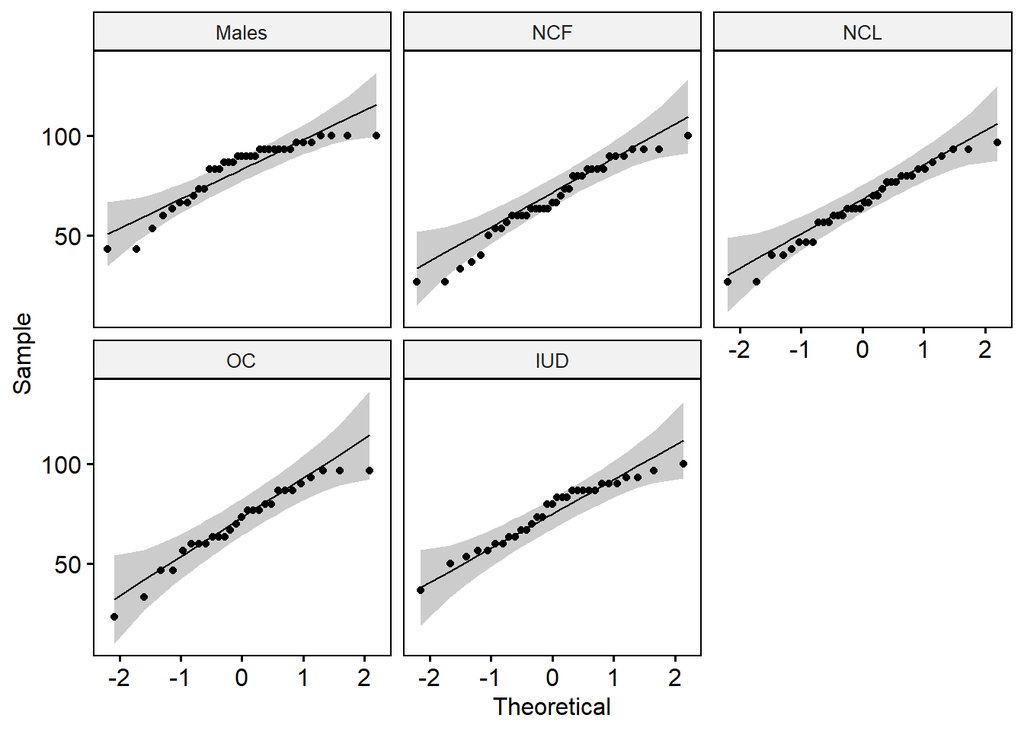

```r
ggqqplot(CST_full_parameters, "accu", facet.by = "Group")
```

```r
# Fit the model, the covariate goes first
model <- lm(accu ~ Group + Age + STEM, data = CST_full_parameters)
```

```r
model.metrics <- augment(model) |>
  dplyr::select(-.hat, -.sigma, -.fitted)
```

```r
# Assess normality of residuals using shapiro wilk test
shapiro_test(model.metrics$.resid)
```

```
# A tibble: 1 × 3
  variable             statistic  p.value
  <chr>                    <dbl>    <dbl>
1 model.metrics$.resid     0.963 0.000212
```

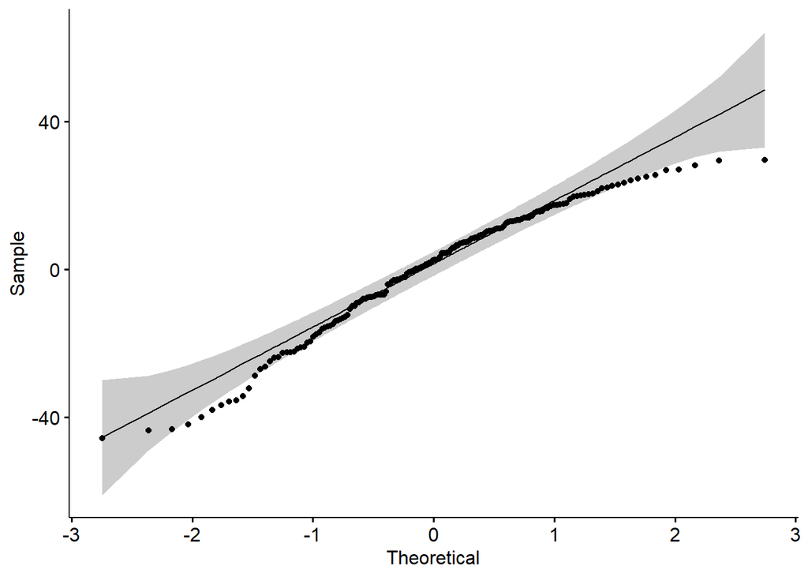

```r
ggqqplot(model.metrics, ".resid")
```

Tested in two ways. With simple Shapiro test on original data and lm model residuals Shapiro test. It looks like celling effect is present, therefore we cannot see normal distribution, however in men N > 30, which let us use central limit theorem.

**Homogeneity of variance**

```r
model.metrics %>% levene_test(.resid ~ Group)
```

```
# A tibble: 1 × 4
    df1   df2 statistic     p
  <int> <int>     <dbl> <dbl>
1     4   161     0.803 0.525
```

The assumption is not violated. Over all, the data is fit to use parametric statistics.

#### ANOVA

```r
aov_1 <- CST_full_parameters |>
  anova_test(accu ~ Age + STEM + Group)
get_anova_table(aov_1)
```

```
ANOVA Table (type II tests)

  Effect DFn DFd     F     p p<.05   ges
1    Age   1 159 0.330 0.567       0.002
2   STEM   1 159 2.617 0.108       0.016
3  Group   4 159 4.203 0.003     * 0.096
```

#### Pairwise comparison:

```r
pwc <- CST_full_parameters |>
  tukey_hsd(
    accu ~ Group, covariate = Age
    )
pwc
```

```
# A tibble: 10 × 9
   term  group1 group2 null.value estimate conf.low conf.high    p.adj
 * <chr> <chr>  <chr>       <dbl>    <dbl>    <dbl>     <dbl>    <dbl>
 1 Group Males  NCF             0   -15.6    -27.1    -4.06   0.00243
 2 Group Males  NCL             0   -17.7    -29.3    -6.08   0.000412
 3 Group Males  OC              0   -12.6    -25.1    -0.0717 0.0479
 4 Group Males  IUD             0    -7.63   -19.7     4.42   0.408
 5 Group NCF    NCL             0    -2.10   -13.5     9.34   0.987
 6 Group NCF    OC              0     2.99    -9.38   15.4    0.963
 7 Group NCF    IUD             0     7.95    -3.95   19.9    0.353
 8 Group NCL    OC              0     5.09    -7.35   17.5    0.791
 9 Group NCL    IUD             0    10.1     -1.93   22.0    0.145
10 Group OC     IUD             0     4.96    -7.91   17.8    0.825
# ℹ 1 more variable: p.adj.signif <chr>
```

```r
CST_full_parameters |>
  group_by(Group) |>
  get_summary_stats(accu, type = "mean_se")
```

```
# A tibble: 5 × 5
  Group variable     n  mean    se
  <fct> <fct>    <dbl> <dbl> <dbl>
1 Males accu        35  83.3  2.68
2 NCF   accu        37  67.7  3.18
3 NCL   accu        36  65.6  3.02
4 OC    accu        27  70.7  3.67
5 IUD   accu        31  75.7  2.84
```

```r
CST_full_parameters |>
  group_by(STEM) |>
  get_summary_stats(accu, type = "mean_se")
```

```
# A tibble: 2 × 5
  STEM  variable     n  mean    se
  <fct> <fct>    <dbl> <dbl> <dbl>
1 0     accu        97  69.0  1.84
2 1     accu        69  77.5  2.22
```

#### Graphic

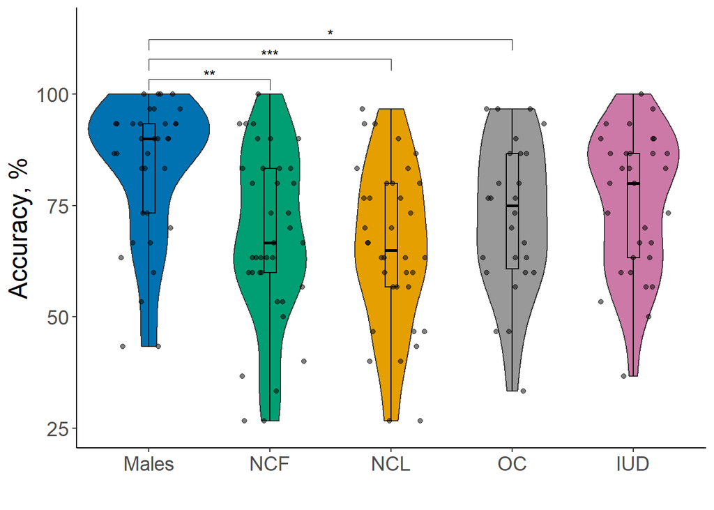

```r
pwc <- pwc |> add_xy_position(x = "Group")
pwc$y.position <- pwc$y.position+3
Anova_result <- ggplot(CST_full_parameters, aes(Group, accu)) +
  geom_violin(aes(fill = Group), width = 1) +
  geom_boxplot(aes(fill = Group), width = 0.1, color = "black", alpha = 0.2) +
  geom_jitter(width = 0.3, height = 0, alpha = 0.5, color = "black") +
  labs(x = " ", y = "Accuracy, %") +
  scale_fill_manual(values = c("#0072B2", "#009E73", "#E69F00", "#999999", "#CC79A7")) +
  scale_y_continuous(limits = c(25, 115)) +  # Set y-axis limits
  theme_classic() +
  theme(axis.text = element_text(size = 14), legend.position = "none") +
  theme(axis.title = element_text(size = 18)) +
  stat_pvalue_manual(pwc, step.increase = 0.05, hide.ns = TRUE)


Anova_result
```

```r
#ggsave("figures/Anova_result.png", Anova_result, width = 6, height = 4.5)
```

### Aditional OC analysis

```r
cycle_info <- read_excel("Info_hc.xlsx")
```

```r
cycle_info <- cycle_info |>  mutate(Group = as.factor(Group),
                                Cycle_day = as.numeric(Cycle_day))
```

```r
CST_data_plus <- CST_full_parameters |> left_join(cycle_info, by = "Subject")
```

```r
just_OC <- CST_data_plus |>
  filter(Group.x == "OC") |>
  group_by(E_conc) |>
  drop_na(E_conc) |>
  mutate(E_conc = as.factor(E_conc))
```

```r
just_OC |>
  get_summary_stats(accu, type = "mean_sd")
```

```
# A tibble: 2 × 5
  E_conc variable     n  mean    sd
  <fct>  <fct>    <dbl> <dbl> <dbl>
1 0.02   accu         9  75.2  13.2
2 0.03   accu        15  66.2  22.7
```

```r
t_test_result <- t.test(accu ~ E_conc, data = just_OC)
```

```r
t_test_result
```

```
    Welch Two Sample t-test

data:  accu by E_conc
t = 1.2201, df = 21.999, p-value = 0.2353
alternative hypothesis: true difference in means between group 0.02 and group 0.03 is not equal to 0
95 percent confidence interval:
 -6.271491 24.197417
sample estimates:
mean in group 0.02 mean in group 0.03
          75.18519           66.22222
```

```r
res <- wilcox.test(accu ~ E_conc, data = just_OC, exact = FALSE)
res
```

```
    Wilcoxon rank sum test with continuity correction

data:  accu by E_conc
W = 84, p-value = 0.3382
alternative hypothesis: true location shift is not equal to 0
```

### 1.3. Linear regression model

### 1.3.1 Women

#### Running first LM model with all the variables

```r
# Separate numeric and factor variables
numeric_vars <- sapply(women_data, is.numeric)
factor_vars <- sapply(women_data, is.factor)

# Standardize numeric variables
scaled_numeric_data <- as.data.frame(scale(women_data[, numeric_vars]))

# Combine standardized numeric variables with original factor variables
final_data <- cbind(scaled_numeric_data, women_data[, factor_vars])
```

```r
women_lm_model <- lm(accu~ OC + IUD + NCL + Age + STEM + PANAS_PA + PANAS_NA + EA1 + EA2 + Tiredness_1 + Tiredness_2 + Femininity + Masculinity + P4 + E2 +Tes, data = final_data)
```

```r
summary(women_lm_model)
```

```
Call:
lm(formula = accu ~ OC + IUD + NCL + Age + STEM + PANAS_PA +
    PANAS_NA + EA1 + EA2 + Tiredness_1 + Tiredness_2 + Femininity +
    Masculinity + P4 + E2 + Tes, data = final_data)

Residuals:
     Min       1Q   Median       3Q      Max
-2.45823 -0.62628  0.07818  0.58322  1.71704

Coefficients:
            Estimate Std. Error t value Pr(>|t|)
(Intercept) -0.01253    0.17661  -0.071   0.9436
OC1         -0.23544    0.26425  -0.891   0.3748
IUD1         0.38076    0.23375   1.629   0.1061
NCL1        -0.22655    0.26442  -0.857   0.3934
Age         -0.13298    0.09930  -1.339   0.1832
STEM1        0.09668    0.19872   0.486   0.6276
PANAS_PA    -0.04009    0.10694  -0.375   0.7084
PANAS_NA    -0.05544    0.09223  -0.601   0.5490
EA1          0.07929    0.09603   0.826   0.4107
EA2         -0.39000    0.09556  -4.081 8.34e-05 ***
Tiredness_1 -0.05004    0.09055  -0.553   0.5816
Tiredness_2 -0.02000    0.09722  -0.206   0.8374
Femininity  -0.09514    0.09703  -0.980   0.3289
Masculinity  0.17319    0.09242   1.874   0.0635 .
P4           0.02564    0.11049   0.232   0.8169
E2           0.07869    0.09690   0.812   0.4185
Tes         -0.16836    0.09503  -1.772   0.0791 .
---
Signif. codes:  0 '***' 0.001 '**' 0.01 '*' 0.05 '.' 0.1 ' ' 1

Residual standard error: 0.9293 on 114 degrees of freedom
Multiple R-squared:  0.2427,    Adjusted R-squared:  0.1364
F-statistic: 2.284 on 16 and 114 DF,  p-value: 0.0062
```

#### Multicolinearity check up

```r
vif(women_lm_model)
```

```
         OC         IUD         NCL         Age        STEM    PANAS_PA
   1.733330    1.497264    2.113737    1.484505    1.350925    1.721617
   PANAS_NA         EA1         EA2 Tiredness_1 Tiredness_2  Femininity
   1.280535    1.388302    1.374699    1.234426    1.422971    1.417385
Masculinity          P4          E2         Tes
   1.285786    1.837944    1.413568    1.359608
```

All VIF score < 3, no multicolinearity

#### AIC procedure

```r
stepAIC(women_lm_model, direction = "backward")
```

```
Start:  AIC=-3.43
accu ~ OC + IUD + NCL + Age + STEM + PANAS_PA + PANAS_NA + EA1 +
    EA2 + Tiredness_1 + Tiredness_2 + Femininity + Masculinity +
    P4 + E2 + Tes

              Df Sum of Sq     RSS     AIC
- Tiredness_2  1    0.0365  98.482 -5.3777
- P4           1    0.0465  98.492 -5.3645
- PANAS_PA     1    0.1214  98.567 -5.2649
- STEM         1    0.2044  98.650 -5.1546
- Tiredness_1  1    0.2637  98.709 -5.0759
- PANAS_NA     1    0.3120  98.757 -5.0117
- E2           1    0.5694  99.015 -4.6708
- EA1          1    0.5886  99.034 -4.6454
- NCL          1    0.6339  99.079 -4.5855
- OC           1    0.6855  99.131 -4.5173
- Femininity   1    0.8302  99.275 -4.3262
<none>                      98.445 -3.4263
- Age          1    1.5486  99.994 -3.3816
- IUD          1    2.2914 100.737 -2.4121
- Tes          1    2.7102 101.155 -1.8687
- Masculinity  1    3.0328 101.478 -1.4515
- EA2          1   14.3838 112.829 12.4386

Step:  AIC=-5.38
accu ~ OC + IUD + NCL + Age + STEM + PANAS_PA + PANAS_NA + EA1 +
    EA2 + Tiredness_1 + Femininity + Masculinity + P4 + E2 +
    Tes

              Df Sum of Sq     RSS     AIC
- P4           1    0.0531  98.535 -7.3071
- PANAS_PA     1    0.1179  98.600 -7.2209
- STEM         1    0.1810  98.663 -7.1371
- Tiredness_1  1    0.3753  98.857 -6.8794
- PANAS_NA     1    0.3911  98.873 -6.8584
- E2           1    0.5553  99.037 -6.6411
- EA1          1    0.6043  99.086 -6.5763
- NCL          1    0.7280  99.210 -6.4128
- OC           1    0.7407  99.222 -6.3962
- Femininity   1    0.8712  99.353 -6.2239
```

[output cut: 142 more lines]

```
- Masculinity  1    3.9732 105.09 -14.8684
- IUD          1    4.5061 105.62 -14.2058
- EA2          1   15.9862 117.10  -0.6896

Step:  AIC=-19.61
accu ~ IUD + Age + EA2 + Femininity + Masculinity + Tes

              Df Sum of Sq    RSS     AIC
<none>                     101.36 -19.607
- Femininity   1    2.0784 103.44 -18.948
- Tes          1    2.1106 103.47 -18.907
- Age          1    2.2421 103.60 -18.741
- Masculinity  1    3.8899 105.25 -16.674
- IUD          1    6.0117 107.37 -14.059
- EA2          1   16.0837 117.44  -2.313
```

```
Call:
lm(formula = accu ~ IUD + Age + EA2 + Femininity + Masculinity +
    Tes, data = final_data)

Coefficients:
(Intercept)         IUD1          Age          EA2   Femininity  Masculinity
    -0.1230       0.5196      -0.1330      -0.3579      -0.1309       0.1795
        Tes
    -0.1313
```

As model suggest that IUD group differ from all other females, I would designate IUD group as reference group and in this case I will account for all hormonal status groups.

#### Final model

```r
women_final <- lm(accu ~ OC + NCF + NCL + Age + EA2 + Femininity + Masculinity + Tes, data  = final_data)
```

```r
summary(women_final)
```

```
Call:
lm(formula = accu ~ OC + NCF + NCL + Age + EA2 + Femininity +
    Masculinity + Tes, data = final_data)

Residuals:
     Min       1Q   Median       3Q      Max
-2.41323 -0.58790  0.06449  0.66455  1.69607

Coefficients:
            Estimate Std. Error t value Pr(>|t|)
(Intercept)  0.40283    0.16725   2.409   0.0175 *
OC1         -0.60673    0.26296  -2.307   0.0227 *
NCF1        -0.41250    0.22387  -1.843   0.0678 .
NCL1        -0.58685    0.22782  -2.576   0.0112 *
Age         -0.14936    0.08410  -1.776   0.0782 .
EA2         -0.36489    0.08173  -4.464  1.8e-05 ***
Femininity  -0.13507    0.08408  -1.606   0.1108
Masculinity  0.18120    0.08277   2.189   0.0305 *
Tes         -0.14282    0.08668  -1.648   0.1020
---
Signif. codes:  0 '***' 0.001 '**' 0.01 '*' 0.05 '.' 0.1 ' ' 1

Residual standard error: 0.9082 on 122 degrees of freedom
Multiple R-squared:  0.2259,    Adjusted R-squared:  0.1752
F-statistic: 4.451 on 8 and 122 DF,  p-value: 9.355e-05
```

#### Assumption testing

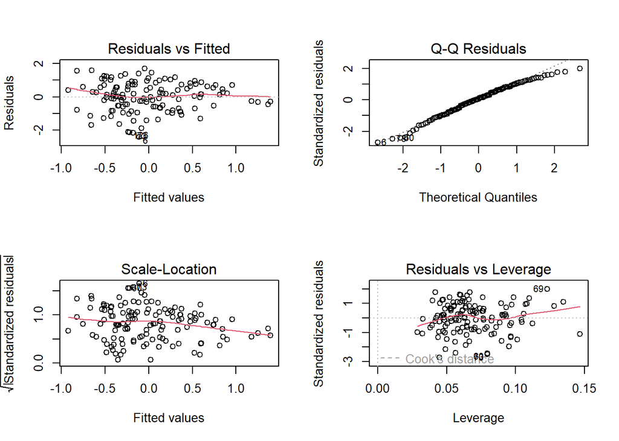

**Homoscedasticity test**

```r
bptest(women_final)
```

```
    studentized Breusch-Pagan test

data:  women_final
BP = 9.1153, df = 8, p-value = 0.3327
```

Homoscedacity assumption is not violated, p > 0.05

**Independence of Errors test:**

```r
durbinWatsonTest(women_final)
```

```
 lag Autocorrelation D-W Statistic p-value
   1     -0.07088107      2.139948   0.602
 Alternative hypothesis: rho != 0
```

Independence of errors assumption is not violated p > 0.05.

**Conclusion:** The model show good fit.

#### Polynomial regression analysis for testosterone

```r
quadratic_model_women <- lm(accu  ~ poly(Tes, 2, raw = TRUE), data = final_data)
summary(quadratic_model_women)
```

```
Call:
lm(formula = accu ~ poly(Tes, 2, raw = TRUE), data = final_data)

Residuals:
     Min       1Q   Median       3Q      Max
-2.52839 -0.52477 -0.06261  0.81554  1.71900

Coefficients:
                          Estimate Std. Error t value Pr(>|t|)
(Intercept)               -0.02500    0.11044  -0.226    0.821
poly(Tes, 2, raw = TRUE)1 -0.07157    0.09500  -0.753    0.453
poly(Tes, 2, raw = TRUE)2  0.02519    0.06744   0.374    0.709

Residual standard error: 1.006 on 128 degrees of freedom
Multiple R-squared:  0.004493,  Adjusted R-squared:  -0.01106
F-statistic: 0.2889 on 2 and 128 DF,  p-value: 0.7496
```

No quadratic effect of testosterone.

### 1.3.2. Men

**Tidying the table**

```r
# Separate numeric and factor variables
numeric_vars_men <- sapply(men_data, is.numeric)
factor_vars_men <- sapply(men_data, is.factor)

# Standardize numeric variables
scaled_numeric_data_men <- as.data.frame(scale(men_data[, numeric_vars_men]))

# Combine standardized numeric variables with original factor variables
final_data_men <- cbind(scaled_numeric_data_men, men_data[, factor_vars_men])
```

#### Running first LM model with all the variables

```r
men_lm_model <- lm(accu~ Age + STEM + PANAS_PA + PANAS_NA + EA1 + EA2 + Tiredness_1 + Tiredness_2 + Femininity + Masculinity +Tes, data = final_data_men)
```

```r
summary(men_lm_model)
```

```
Call:
lm(formula = accu ~ Age + STEM + PANAS_PA + PANAS_NA + EA1 +
    EA2 + Tiredness_1 + Tiredness_2 + Femininity + Masculinity +
    Tes, data = final_data_men)

Residuals:
    Min      1Q  Median      3Q     Max
-2.2288 -0.5176  0.1540  0.5306  1.0881

Coefficients:
            Estimate Std. Error t value Pr(>|t|)
(Intercept) -0.25151    0.32475  -0.774   0.4465
Age         -0.02428    0.19803  -0.123   0.9035
STEM1        0.36678    0.40688   0.901   0.3767
PANAS_PA    -0.26559    0.28222  -0.941   0.3564
PANAS_NA    -0.11750    0.22820  -0.515   0.6116
EA1          0.46799    0.20803   2.250   0.0343 *
EA2         -0.21654    0.21671  -0.999   0.3281
Tiredness_1 -0.39619    0.23478  -1.688   0.1050
Tiredness_2  0.08833    0.22081   0.400   0.6928
Femininity   0.04580    0.23245   0.197   0.8455
Masculinity  0.29551    0.23224   1.272   0.2159
Tes         -0.29856    0.21653  -1.379   0.1812
---
Signif. codes:  0 '***' 0.001 '**' 0.01 '*' 0.05 '.' 0.1 ' ' 1

Residual standard error: 0.9832 on 23 degrees of freedom
Multiple R-squared:  0.346, Adjusted R-squared:  0.03324
F-statistic: 1.106 on 11 and 23 DF,  p-value: 0.3996
```

```r
vif(men_lm_model)
```

```
        Age        STEM    PANAS_PA    PANAS_NA         EA1         EA2
   1.379246    1.291679    2.801078    1.831497    1.521960    1.651588
Tiredness_1 Tiredness_2  Femininity Masculinity         Tes
   1.938527    1.714781    1.900355    1.896910    1.648861
```

#### AIC procedure

```r
stepAIC(men_lm_model, direction = "backward")
```

```
Start:  AIC=8.12
accu ~ Age + STEM + PANAS_PA + PANAS_NA + EA1 + EA2 + Tiredness_1 +
    Tiredness_2 + Femininity + Masculinity + Tes

              Df Sum of Sq    RSS     AIC
- Age          1    0.0145 22.250  6.1447
- Femininity   1    0.0375 22.273  6.1809
- Tiredness_2  1    0.1547 22.390  6.3645
- PANAS_NA     1    0.2563 22.492  6.5230
- STEM         1    0.7856 23.021  7.3371
- PANAS_PA     1    0.8562 23.092  7.4443
- EA2          1    0.9653 23.201  7.6092
<none>                     22.235  8.1218
- Masculinity  1    1.5652 23.801  8.5027
- Tes          1    1.8381 24.073  8.9017
- Tiredness_1  1    2.7530 24.988 10.2073
- EA1          1    4.8928 27.128 13.0829

Step:  AIC=6.14
accu ~ STEM + PANAS_PA + PANAS_NA + EA1 + EA2 + Tiredness_1 +
    Tiredness_2 + Femininity + Masculinity + Tes

              Df Sum of Sq    RSS     AIC
- Femininity   1    0.0299 22.280  4.1917
- Tiredness_2  1    0.1505 22.400  4.3806
- PANAS_NA     1    0.2418 22.492  4.5230
- STEM         1    0.7737 23.024  5.3412
- PANAS_PA     1    0.8742 23.124  5.4936
- EA2          1    0.9702 23.220  5.6385
<none>                     22.250  6.1447
- Masculinity  1    1.5658 23.816  6.5250
- Tes          1    1.8372 24.087  6.9215
- Tiredness_1  1    2.8796 25.130  8.4044
- EA1          1    4.8999 27.150 11.1109

Step:  AIC=4.19
accu ~ STEM + PANAS_PA + PANAS_NA + EA1 + EA2 + Tiredness_1 +
    Tiredness_2 + Masculinity + Tes

              Df Sum of Sq    RSS     AIC
```

[output cut: 81 more lines]

```

Step:  AIC=-2.57
accu ~ EA1 + EA2

       Df Sum of Sq    RSS     AIC
- EA2   1    1.3482 28.745 -2.8907
<none>              27.397 -2.5720
- EA1   1    5.8796 33.277  2.2327

Step:  AIC=-2.89
accu ~ EA1

       Df Sum of Sq    RSS      AIC
<none>              28.745 -2.89071
- EA1   1    5.2548 34.000  0.98544
```

```
Call:
lm(formula = accu ~ EA1, data = final_data_men)

Coefficients:
(Intercept)          EA1
  2.372e-16    3.931e-01
```

#### Final model

```r
men_final <- lm(accu ~ EA1, data = final_data_men)
```

```r
summary(men_final)
```

```
Call:
lm(formula = accu ~ EA1, data = final_data_men)

Residuals:
    Min      1Q  Median      3Q     Max
-2.2891 -0.4796  0.2292  0.6270  1.3578

Coefficients:
             Estimate Std. Error t value Pr(>|t|)
(Intercept) 2.372e-16  1.578e-01   0.000   1.0000
EA1         3.931e-01  1.601e-01   2.456   0.0195 *
---
Signif. codes:  0 '***' 0.001 '**' 0.01 '*' 0.05 '.' 0.1 ' ' 1

Residual standard error: 0.9333 on 33 degrees of freedom
Multiple R-squared:  0.1546,    Adjusted R-squared:  0.1289
F-statistic: 6.033 on 1 and 33 DF,  p-value: 0.01948
```

#### Assumptions testing

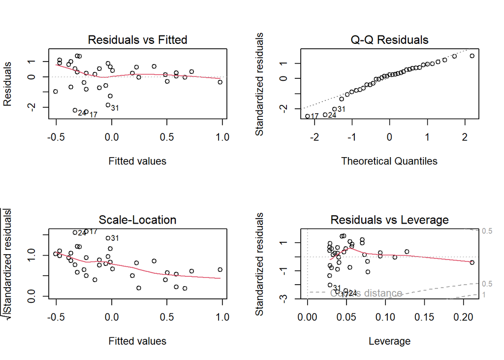

**Normality of residuals**

```r
ad.test(model.metrics.men$.resid)
```

```
    Anderson-Darling normality test

data:  model.metrics.men$.resid
A = 0.72376, p-value = 0.05371
```

IN QQ plot we can see that there is three outliers, otherwise the plot looks normal. At larger sample sizes the Shapiro-Wilk test becomes very sensitive even to a minor deviation from normality. Anderson-Darling normality test p > 0.05, therefore I assume normal distribution.

**Homoscedasticity test**

```r
bptest(men_final)
```

```
    studentized Breusch-Pagan test

data:  men_final
BP = 4.5156, df = 1, p-value = 0.03359
```

**Independence of Errors test:**

```r
durbinWatsonTest(men_final)
```

```
 lag Autocorrelation D-W Statistic p-value
   1      -0.2919854      2.572277   0.078
 Alternative hypothesis: rho != 0
```

The independence of error assumption is not violated.

**Conclusion:** Some assumptions are violated therefore the model should be interpreted with cautious.

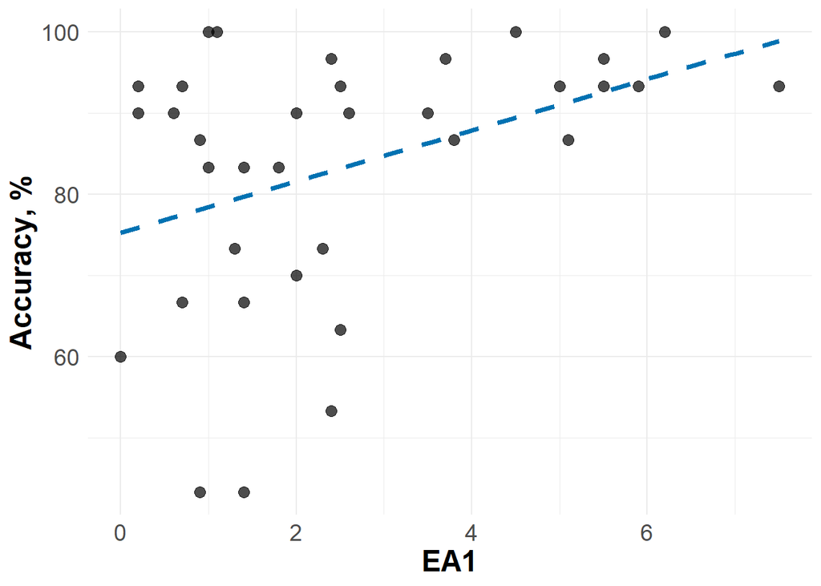

```r
men_lm <- ggplot(men_data, aes(x = EA1, y = accu)) +
  geom_point(size = 3, alpha = 0.7) +  # Adjusting point
  geom_smooth(method = "lm", se = FALSE, color = "#0072B2", linetype = "dashed", size = 1.5) +  # Adjusting smooth line aesthetics
  theme_minimal() +
  labs(x = "EA1", y = "Accuracy, %") +  # Adding axis labels and title
  theme(plot.title = element_text(size = 14, face = "bold"),  # Adjusting title font size and style
        axis.text = element_text(size = 14),  # Adjusting axis text size
        axis.title = element_text(size = 18, face = "bold"))  # Adjusting axis title size and style
men_lm
```

#### Additional boostrap analysis

```r
corr_men <- men_data |> dplyr::select(accu, Age, STEM, PANAS_PA, PANAS_NA, EA1, EA2, Tiredness_1, Tiredness_2, Femininity, Masculinity, Tes) |> mutate(STEM = as.numeric(STEM))
```

```r
# Load necessary library
library(boot)
# Function to compute correlation of "accu" with all other variables
bootstrap_corr <- function(data, indices) {
  boot_sample <- data[indices, ]  # Resample the data
  cor_values <- cor(boot_sample$accu, boot_sample[, -1], use = "pairwise.complete.obs")  # Correlation with accu
  return(cor_values)  # Returns vector of correlations
}

# Perform bootstrapping with 1000 resamples
set.seed(123)  # Ensure reproducibility
boot_res <- boot(data = corr_men, statistic = bootstrap_corr, R = 10000)

# Compute 95% confidence intervals for each variable
boot_ci_list <- lapply(1:ncol(corr_men[-1]), function(i) {
  boot.ci(boot_res, type = "perc", index = i)
})

# Extract results into a readable format
ci_results <- data.frame(
  Variable = colnames(corr_men)[-1],  # All variables except "accu"
  Correlation = colMeans(boot_res$t),  # Mean of bootstrap correlations
  Lower_CI = sapply(boot_ci_list, function(ci) ci$percent[4]),  # 2.5% percentile
  Upper_CI = sapply(boot_ci_list, function(ci) ci$percent[5])   # 97.5% percentile
)

# Print final table of correlations with confidence intervals
print(ci_results)
```

```
      Variable  Correlation    Lower_CI  Upper_CI
1          Age  0.202213286 -0.06588518 0.4405767
2         STEM  0.130541236 -0.21490479 0.4724532
3     PANAS_PA -0.061310048 -0.39585382 0.2878176
4     PANAS_NA  0.066137490 -0.22021708 0.3542529
5          EA1  0.393843603  0.18148877 0.5847059
6          EA2 -0.147657143 -0.45161454 0.1670989
7  Tiredness_1 -0.156531523 -0.48951551 0.2175793
8  Tiredness_2 -0.193714934 -0.53958597 0.1891741
9   Femininity  0.137932074 -0.20135459 0.4712800
10 Masculinity  0.008779112 -0.36108715 0.3820459
11         Tes -0.171608191 -0.42153921 0.1076781
```

```r
#ggsave("figures/men_lm.png", men_lm, width = 6, height = 4.5)
```

#### Polynomial regression analysis for testosterone

```r
quadratic_model_men <- lm(accu ~ poly(Tes, 2, raw = TRUE), data = final_data_men)
```

```r
summary(quadratic_model_men)
```

```
Call:
lm(formula = accu ~ poly(Tes, 2, raw = TRUE), data = final_data_men)

Residuals:
    Min      1Q  Median      3Q     Max
-2.5766 -0.5655  0.3496  0.7468  1.2219

Coefficients:
                          Estimate Std. Error t value Pr(>|t|)
(Intercept)                -0.1082     0.2162  -0.500    0.620
poly(Tes, 2, raw = TRUE)1  -0.1694     0.1725  -0.982    0.333
poly(Tes, 2, raw = TRUE)2   0.1114     0.1376   0.810    0.424

Residual standard error: 1.006 on 32 degrees of freedom
Multiple R-squared:  0.04816,   Adjusted R-squared:  -0.01133
F-statistic: 0.8095 on 2 and 32 DF,  p-value: 0.454
```

No quadratic effect of testosterone

### 1.4 Mediation analysis

*Output of mediation analysis is not accessible as PROCESS v4.3 functions available as script, not a R package.*

```r
CST_full_parameters <- CST_full_parameters |>
                          mutate(Group = as.numeric(Group),
                                STEM = as.numeric(STEM),
                                Sex =  as.numeric(Sex))
```

```r
process (data = CST_full_parameters, y = "accu", x = "Sex", m ="EA2", model = 4, effsize =1, total =1, stand =1, cov = c("Group","Age","STEM"), boot = 10000 , seed = 654321)
```

Percentage of the sex difference explained by EA2

```r
Proc_EA <- (0.1801*100)/0.9632
Proc_EA
```

```
[1] 18.69809
```